# R Notebook

# Evaluating Modelling Techniques to Detect Precursors to Landslides from InSAR-Based Data

**2026 Honours Project -**

```r
# Load packages

library(readxl)
library(ggplot2)
library(MASS)
library(factoextra)
library(gridExtra)
library(cluster)
library(clusterSim)
library(dbscan)
library(dtwclust)
library(patchwork)
library(ggplotify)
library(zoo)
library(tidyr)
library(dplyr)


set.seed(1234)
```

## 1. Prepare the data

Below is the original data. The next section defines the data that subsets only the TSF area points.

```r
cadia <- read_excel("../data/Cadia_PS_2018.xlsx")

peru_failed <- read_excel("../data/Cobriza_Peru_Failed_2019.xlsx")

peru_unfailed <- read_excel("../data/Cobriza_Peru_Unfailed_2019.xlsx")

feijao_53 <- read_excel("../data/Feijao_PS_T53.xlsx")

feijao_155 <- read_excel("../data/Feijao_PS_T155.xlsx")
```

```r
head(cadia)
dim(cadia)

head(peru_failed)
dim(peru_failed)

head(peru_unfailed)
dim(peru_unfailed)

head(feijao_53)
dim(feijao_53)

head(feijao_155)
dim(feijao_155)
```

**Extract the displacement columns:**

```r
# Cadia --------------

d_cols <- grep("^D_", names(cadia), value = TRUE) # D_ for descending orbit track
length(d_cols)
head(d_cols)

cadia_D <- cadia[, d_cols]

# Inspect new dataset
head(cadia_D)
dim(cadia_D)

# Check for missing vals
sum(is.na(cadia_D))

# Peru - (Failed) ---------------------

d_cols_peru_F <- grep("^D_", names(peru_failed), value = TRUE)
length(d_cols_peru_F)
head(d_cols_peru_F)

peru_D_F <- peru_failed[, d_cols_peru_F]

head(peru_D_F)
dim(peru_D_F)

# Check for missing vals
sum(is.na(peru_D_F))

# Peru - (Unfailed) ---------------------

d_cols_peru_U <- grep("^D_", names(peru_unfailed), value = TRUE)
length(d_cols_peru_U)
head(d_cols_peru_U)

peru_D_U <- peru_unfailed[, d_cols_peru_U]

head(peru_D_U)
dim(peru_D_U)

# Check for missing vals
sum(is.na(peru_D_U))
```

**Transform into matrices:**

```r
cadia_D_mat <- as.matrix(cadia_D)
peru_D_F_mat <- as.matrix(peru_D_F)
peru_D_U_mat <- as.matrix(peru_D_U)
```

**Remove baseline date column:**

```r
# Helper function for removing baseline date column
remove_zero_var <- function(x) {
  col_sd <- apply(x, 2, sd)
  x[, col_sd > 0, drop = FALSE]
}
```

```r
cadia_D <- remove_zero_var(cadia_D_mat)
peru_D_F <- remove_zero_var(peru_D_F_mat)
peru_D_U <- remove_zero_var(peru_D_U_mat)
```

```r
dim(cadia_D)
dim(peru_D_F)
dim(peru_D_U)
```

## 2. Subsetting the data

### 2.1 TSF Only Selection

Also adding selection of smaller subset of points (targeted around the dam only).

```r
# read smaller region csv

cadia_tsf_only <- read.csv("../data/cadia_filtered_tsf_only.csv")

head(cadia_tsf_only)
dim(cadia_tsf_only)
```

```r
library(ggplot2)

ggplot(cadia, aes(x = lon, y = lat)) +
  geom_point(size = 0.5) +
  coord_fixed() +
  labs(
    title = "Cadia InSAR points",
    x = "Longitude",
    y = "Latitude"
  )

ggplot(cadia_tsf_only, aes(x = lon, y = lat)) +
  geom_point(size = 0.5) +
  coord_fixed() +
  labs(
    title = "Cadia TSF InSAR points",
    x = "Longitude",
    y = "Latitude"
  )
```

### 2.2 Coherence Filtering

```r
coherence_thresholds <- c(0.55, 0.60, 0.70)

for (t in coherence_thresholds) {

  n_keep <- sum(cadia_tsf_only$coherence >= t)
  pct_keep <- mean(cadia_tsf_only$coherence >= t) * 100

  cat(
    "Threshold:", t,
    "- Points:", n_keep,
    "- Percent:", round(pct_keep, 1), "%\n"
  )
}
```

Choosing 0.70 as Rana et al. did.

**Setup:**

```r
cadia_coherence_threshold <- 0.70

cadia_co_filtered <- cadia_tsf_only %>%
  filter(coherence >= cadia_coherence_threshold)

nrow(cadia_co_filtered)
```

```r
# extract displacement cols

d_cols_filtered <- grep(
  "^D_",
  names(cadia_co_filtered),
  value = TRUE
)

cadia_D_filtered <- cadia_co_filtered[, d_cols_filtered]

cadia_D_filtered <- as.matrix(cadia_D_filtered)
```

```r
# remove 0 var dates
cadia_D_filtered_0 <- remove_zero_var(cadia_D_filtered)
```

## 3. Sliding Window Temporal Clustering Workflow

### 3.1 Median Cumulative Displacement Version

```r
# filtered cadia dataset including 0 baseline
cadia_D_filtered_sliding <- cadia_D_filtered
```

```r
dim(cadia_D_filtered_sliding)
```

#### 3.1.1 K = 2

```r
# temporal clustering setup
# sliding window size 3

set.seed(1234)

k <- 2
window_size <- 3
threshold <- -3

n_pts_filtered <- nrow(cadia_D_filtered_sliding)
n_dates_filtered <- ncol(cadia_D_filtered_sliding)

# number of overlapping sliding windows
n_iters_filtered <- n_dates_filtered - window_size + 1

# final date represents each window
iter_dates_filtered <- colnames(cadia_D_filtered_sliding)[
  window_size:n_dates_filtered
]
```

```r
# raw K-means membership
cluster_membership_mat_sliding_k2 <- matrix(
  NA,
  nrow = n_pts_filtered,
  ncol = n_iters_filtered
)

colnames(cluster_membership_mat_sliding_k2) <- paste0(
  "cluster_",
  sub("^D_", "", iter_dates_filtered)
)


# fixed-threshold status
cluster_status_mat_sliding_k2 <- matrix(
  NA,
  nrow = n_pts_filtered,
  ncol = n_iters_filtered
)

colnames(cluster_status_mat_sliding_k2) <- paste0(
  "cluster_",
  sub("^D_", "", iter_dates_filtered)
)


# ordered cluster medians
cluster_medians_mat_sliding_k2 <- matrix(
  NA,
  nrow = n_iters_filtered,
  ncol = k
)

colnames(cluster_medians_mat_sliding_k2) <- c(
  "Lower median",
  "Higher median"
)


# silhouette score for each window
silhouette_disp_k2_w3 <- numeric(n_iters_filtered)
```

```r
set.seed(1234)

for (i in window_size:n_dates_filtered) {

  start_idx <- i - window_size + 1

  # extract current 3-date window
  x <- cadia_D_filtered_sliding[
    , start_idx:i,
    drop = FALSE
  ]

  # reset each point to 0 at beginning of window
  x <- sweep(
    x,
    1,
    x[, 1],
    FUN = "-"
  )

  # K-means
  km <- kmeans(
    x,
    centers = k,
    nstart = 20
  )

  # current iteration
  iter <- i - window_size + 1

  # save raw K-means membership
  cluster_membership_mat_sliding_k2[
    , iter
  ] <- km$cluster

  # newest displacement within window
  latest_disp <- x[, ncol(x)]

  # median newest displacement of each raw cluster
  cluster_medians <- tapply(
    latest_disp,
    km$cluster,
    median
  )

  # sort only for interpretation/plotting
  cluster_medians_mat_sliding_k2[
    iter,
  ] <- sort(cluster_medians)

  # fixed threshold classification
  cluster_status <- ifelse(
    cluster_medians <= threshold,
    1,
    0
  )

  # each point inherits status of its raw cluster
  pt_status <- cluster_status[
    as.character(km$cluster)
  ]

  cluster_status_mat_sliding_k2[
    , iter
  ] <- pt_status

  # silhouette score
  sil <- cluster::silhouette(
    km$cluster,
    dist(x)
  )

  silhouette_disp_k2_w3[iter] <- mean(
    sil[, "sil_width"]
  )
}
```

```r
dim(cluster_membership_mat_sliding_k2)
```

```
[1] 2495   43
```

```r
dim(cluster_status_mat_sliding_k2)
```

```
[1] 2495   43
```

```r
dim(cluster_medians_mat_sliding_k2)
```

```
[1] 43  2
```

```r
head(cluster_medians_mat_sliding_k2)
```

```
     Lower median Higher median
[1,]         -1.0          1.90
[2,]         -1.8          1.80
[3,]         -1.9          0.30
[4,]         -2.4          1.00
[5,]         -1.5          0.50
[6,]         -1.8          1.25
```

```r
tail(cluster_medians_mat_sliding_k2)
```

```
      Lower median Higher median
[38,]         -2.2           7.2
[39,]         -3.1           3.4
[40,]         -3.0           2.1
[41,]         -3.1           4.2
[42,]         -4.2           1.9
[43,]         -2.1           6.6
```

```r
summary(cluster_medians_mat_sliding_k2)
```

```
  Lower median    Higher median
 Min.   :-5.600   Min.   :0.100
 1st Qu.:-2.400   1st Qu.:0.850
 Median :-1.900   Median :1.400
 Mean   :-2.012   Mean   :1.947
 3rd Qu.:-1.500   3rd Qu.:2.100
 Max.   : 0.000   Max.   :7.200
```

```r
table(
  cluster_status_mat_sliding_k2,
  useNA = "ifany"
)
```

```
cluster_status_mat_sliding_k2
     0      1
101475   5810
```

```r
summary(silhouette_disp_k2_w3)
```

```
   Min. 1st Qu.  Median    Mean 3rd Qu.    Max.
 0.3068  0.3403  0.3657  0.3744  0.3844  0.5104
```

```r
mean(silhouette_disp_k2_w3)
```

```
[1] 0.3744002
```

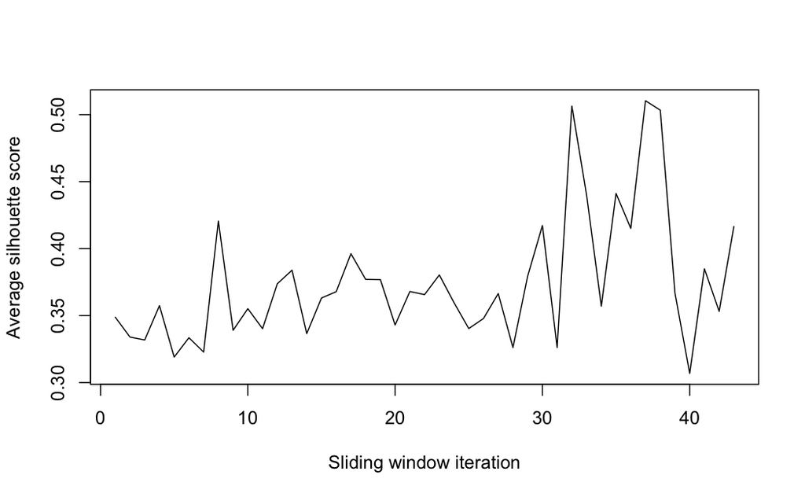

```r
plot(
  silhouette_disp_k2_w3,
  type = "l",
  xlab = "Sliding window iteration",
  ylab = "Average silhouette score"
)
```

```r
# Percentage of points flagged through time
cadia_dates_w3 <- as.Date(
  sub("^D_", "", iter_dates_filtered),
  format = "%Y%m%d"
)

cadia_disp_w3_k2_pct <-
  colMeans(cluster_status_mat_sliding_k2 == 1) * 100

png(
  "../outputs/cadia_sw_km2_disp_w3_threshold_pts.png",
  width = 2400,
  height = 1600,
  res = 300
)

plot(
  cadia_dates_w3,
  cadia_disp_w3_k2_pct,
  type = "l",
  ylim = c(0, 100),
  xlab = "Date",
  ylab = "Points in threshold-exceeding cluster (%)",
  main = "Cadia W3 Displacement K-means (k = 2, threshold = -3 mm)",
  xaxt = "n"
)

axis.Date(
  1,
  at = seq(min(cadia_dates_w3), max(cadia_dates_w3), by = "3 months"),
  format = "%Y-%m"
)

dev.off()
```

**Exporting:**

- From wide to long.

```r
cadia_co_filtered <- cadia_co_filtered %>%
  mutate(PointID = row_number())
```

```r
cadia_info_sliding <- cadia_co_filtered %>%
  select(
    PointID,
    lon,
    lat,
    coherence
  )

cadia_D_filtered_sliding <- cadia_co_filtered %>%
  select(starts_with("D_"))
```

```r
nrow(cadia_D_filtered)
nrow(cadia_D_filtered_sliding)
```

```r
# convert clusters
cadia_sliding_clusters_df <- as.data.frame(
  cluster_membership_mat_sliding_k2
)

cadia_sliding_clusters_df$PointID <- cadia_info_sliding$PointID

cadia_sliding_clusters_long <- cadia_sliding_clusters_df %>%
  pivot_longer(
    cols = -PointID,
    names_to = "Date",
    values_to = "RawCluster"
  )
```

```r
# convert status
cadia_sliding_status_df <- as.data.frame(
  cluster_status_mat_sliding_k2
)

cadia_sliding_status_df$PointID <- cadia_info_sliding$PointID

cadia_sliding_status_long <- cadia_sliding_status_df %>%
  pivot_longer(
    cols = -PointID,
    names_to = "Date",
    values_to = "Status"
  )
```

```r
cadia_sliding_results <- cadia_sliding_clusters_long %>%
  left_join(
    cadia_sliding_status_long,
    by = c("PointID", "Date")
  )
```

```r
# convert dates
cadia_sliding_results <- cadia_sliding_results %>%
  mutate(
    Date = sub("^cluster_", "", Date),
    Date = as.Date(Date, format = "%Y%m%d")
  )
```

```r
head(cadia_sliding_results$Date)
str(cadia_sliding_results$Date)
```

```r
cadia_sliding_results <- cadia_sliding_results %>%
  left_join(
    cadia_info_sliding,
    by = "PointID"
  )
```

```r
names(cadia_sliding_results)
```

```r
write.csv(
  cadia_sliding_results,
  "../outputs/cadia_sliding_k2_w3_threshold2.5.csv",
  row.names = FALSE
)
```

#### 3.1.2 K = 3

```r
# temporal clustering setup
# sliding window size 3 instead of expanding by 1

set.seed(1234)

k <- 3
window_size <- 3
threshold_1 <- -3
threshold_2 <- -5

n_pts_filtered <- nrow(cadia_D_filtered_sliding)
n_dates_filtered <- ncol(cadia_D_filtered_sliding)

# number of overlapping sliding windows
n_iters_filtered <- n_dates_filtered - window_size + 1

# date representing each window = final date in window
iter_dates_filtered <- colnames(cadia_D_filtered_sliding)[
  window_size:n_dates_filtered
]
```

```r
# membership matrix
cluster_membership_mat_sliding_k3 <- matrix(
  NA,
  nrow = n_pts_filtered,
  ncol = n_iters_filtered
)

colnames(cluster_membership_mat_sliding_k3) <- paste0(
  "cluster_",
  sub("^D_", "", iter_dates_filtered)
)
```

```r
# status matrix
cluster_status_mat_sliding_k3 <- matrix(
  NA,
  nrow = n_pts_filtered,
  ncol = n_iters_filtered
)

colnames(cluster_status_mat_sliding_k3) <- paste0(
  "cluster_",
  sub("^D_", "", iter_dates_filtered)
)
```

```r
# medians matrix
cluster_medians_mat_sliding_k3 <- matrix(
  NA,
  nrow = n_iters_filtered,
  ncol = k
)

colnames(cluster_medians_mat_sliding_k3) <- c(
  "Lower median",
  "Middle median",
  "Higher median"
)
```

```r
silhouette_disp_k3_w3 <- numeric(n_iters_filtered)
```

```r
n_iters_filtered
ncol(cluster_membership_mat_sliding_k2)
length(iter_dates_filtered)
```

```r
# temporal clustering loop

for (i in window_size:n_dates_filtered) {

  start_idx <- i - window_size + 1

  x <- cadia_D_filtered_sliding[
    , start_idx:i,
    drop = FALSE
  ]

  # reset each pt to 0 at the start of each window
  x <- sweep(
    x,
    1,
    x[, 1],
    FUN = "-"
  )

  km <- kmeans(
    x,
    centers = k,
    nstart = 20
  )

  # displacement at newest date
  latest_disp <- x[, ncol(x)]

  # current iteration number
  iter <- i - window_size + 1

  sil <- cluster::silhouette(
  km$cluster,
  dist(x)
  )

  silhouette_disp_k3_w3[iter] <- mean(
    sil[, "sil_width"]
  )

  # store raw cluster membership
  cluster_membership_mat_sliding_k3[
    , iter
  ] <- km$cluster

  # median newest displacement
  # for each raw cluster
  cluster_medians <- tapply(
    latest_disp,
    km$cluster,
    median
  )

  # ordered medians only for plotting
  ordered_medians <- sort(
    cluster_medians
  )

  cluster_medians_mat_sliding_k3[
    iter,
  ] <- ordered_medians

  # classify each raw K-means cluster
  cluster_status <- ifelse(
    cluster_medians <= threshold_2,
    2,
    ifelse(
      cluster_medians <= threshold_1,
      1,
      0
    )
  )

  # each point inherits the status of its cluster
  pt_status <- cluster_status[
    as.character(km$cluster)
  ]

  cluster_status_mat_sliding_k3[
    , iter
  ] <- pt_status

}
```

```r
head(cluster_medians_mat_sliding_k3)
tail(cluster_medians_mat_sliding_k3)

summary(cluster_medians_mat_sliding_k3)
```

```r
dim(cluster_membership_mat_sliding_k2)
dim(cluster_status_mat_sliding_k2)
dim(cluster_medians_mat_sliding_k2)
```

We check the medians from the initial test to choose an appropriate threshold.

```r
head(cluster_medians_mat_sliding_k2)
tail(cluster_medians_mat_sliding_k2)
summary(cluster_medians_mat_sliding_k2)
```

```r
thresholds <- c(-2, -2.5, -3, -3.5, -4, -5)

threshold_check <- data.frame(
  Threshold = thresholds,
  WindowsFlagged = sapply(
    thresholds,
    function(th) {
      sum(lower_med <= th, na.rm = TRUE)
    }
  )
)

threshold_check
```

```r
table(cluster_status_mat_sliding_k3)
```

```r
status_pct_k3 <- t(
  apply(
    cluster_status_mat_sliding_k3,
    2,
    function(x) {
      table(factor(x, levels = c(0, 1, 2))) / length(x) * 100
    }
  )
)

colnames(status_pct_k3) <- c(
  "Status0",
  "Status1",
  "Status2"
)

status_pct_k3
```

```
                   Status0   Status1   Status2
cluster_20161015  79.83968 20.160321  0.000000
cluster_20161021  87.93587  0.000000 12.064128
cluster_20161102  90.14028  9.859719  0.000000
cluster_20161114  72.06413 27.935872  0.000000
cluster_20161126  87.01403 12.985972  0.000000
cluster_20161208  78.83768 21.162325  0.000000
cluster_20161220  88.17635 11.823647  0.000000
cluster_20170101  83.44689 16.553106  0.000000
cluster_20170113  79.15832 20.841683  0.000000
cluster_20170125 100.00000  0.000000  0.000000
cluster_20170206  81.92385 18.076152  0.000000
cluster_20170218  74.14830 25.851703  0.000000
cluster_20170302  80.52104 19.478958  0.000000
cluster_20170314  81.36273 18.637275  0.000000
cluster_20170326  78.15631 21.843687  0.000000
cluster_20170407  80.32064 19.679359  0.000000
cluster_20170419  75.15030 24.849699  0.000000
cluster_20170501  75.43086 24.569138  0.000000
cluster_20170513  76.35271 23.647295  0.000000
cluster_20170525  86.61323 13.386774  0.000000
cluster_20170606 100.00000  0.000000  0.000000
cluster_20170618  79.23848 20.761523  0.000000
cluster_20170630  75.87174 24.128257  0.000000
cluster_20170712 100.00000  0.000000  0.000000
cluster_20170724  84.92986 15.070140  0.000000
cluster_20170805 100.00000  0.000000  0.000000
cluster_20170817  90.62124  0.000000  9.378758
cluster_20170829 100.00000  0.000000  0.000000
cluster_20170910  71.30261 28.697395  0.000000
cluster_20170922  93.74749  0.000000  6.252505
cluster_20171004  85.13026 14.869739  0.000000
cluster_20171016  81.20240 18.797595  0.000000
cluster_20171028  75.63126 24.368737  0.000000
cluster_20171109  75.43086 24.569138  0.000000
cluster_20171121  80.84168  0.000000 19.158317
cluster_20171203  78.19639  0.000000 21.803607
cluster_20171215  84.76954  0.000000 15.230461
cluster_20171227  77.39479  0.000000 22.605210
cluster_20180108  80.96192  0.000000 19.038076
cluster_20180120  81.88377  0.000000 18.116232
cluster_20180201  75.31062  0.000000 24.689379
cluster_20180213  77.47495  0.000000 22.525050
cluster_20180225  75.87174  0.000000 24.128257
```

```r
png(
  "../outputs/cadia_sw_km3_disp_w3_threshold_pts.png",
  width = 2400,
  height = 1600,
  res = 300
)

matplot(
  cadia_dates_w3,
  status_pct_k3,
  type = "l",
  lty = 1,
  ylim = c(0, 100),
  xaxt = "n",
  xlab = "Date",
  ylab = "Points in each status category (%)",
  main = "Cadia W3 Displacement K-means (k = 3)"
)

legend(
  x = as.Date("2016-11-15"),
  y = 60,
  legend = c(
    "Status 0 (> -3 mm)",
    "Status 1 (-5 to -3 mm)",
    "Status 2 (<= -5 mm)"
  ),
  lty = 1,
  col = 1:3,
  bty = "n",
  cex = 0.8
)

axis.Date(
  1,
  at = seq(min(cadia_dates_w3), max(cadia_dates_w3), by = "3 months"),
  format = "%Y-%m"
)

dev.off()
```

**Exporting**

```r
# cluster membership conversion
cadia_sliding_clusters_df_k3 <-
  as.data.frame(cluster_membership_mat_sliding_k3)

cadia_sliding_clusters_df_k3$PointID <-
  cadia_info_sliding$PointID

cadia_sliding_clusters_long_k3 <-
  cadia_sliding_clusters_df_k3 %>%
  pivot_longer(
    cols = -PointID,
    names_to = "Date",
    values_to = "RawCluster"
  )
```

```r
# status conversion
cadia_sliding_status_df_k3 <-
  as.data.frame(cluster_status_mat_sliding_k3)

cadia_sliding_status_df_k3$PointID <-
  cadia_info_sliding$PointID

cadia_sliding_status_long_k3 <-
  cadia_sliding_status_df_k3 %>%
  pivot_longer(
    cols = -PointID,
    names_to = "Date",
    values_to = "Status"
  )
```

```r
# combine membership + status
cadia_sliding_results_k3 <-
  cadia_sliding_clusters_long_k3 %>%
  left_join(
    cadia_sliding_status_long_k3,
    by = c("PointID", "Date")
  )
```

```r
cadia_sliding_results_k3 <-
  cadia_sliding_results_k3 %>%
  mutate(
    Date = sub("^cluster_", "", Date),
    Date = as.Date(Date, format = "%Y%m%d")
  )
```

```r
# join other data
cadia_sliding_results_k3 <-
  cadia_sliding_results_k3 %>%
  left_join(
    cadia_info_sliding,
    by = "PointID"
  )
```

```r
names(cadia_sliding_results_k3)
head(cadia_sliding_results_k3)
```

```r
# export
write.csv(
  cadia_sliding_results_k3,
  "../outputs/cadia_sliding_k3_w3_thresholds3_5.csv",
  row.names = FALSE
)
```

**Results check**

1. How many points are flagged at each iteration?

```r
flagged_per_iter <- colSums(
  cluster_status_mat_sliding_k2 == 1,
  na.rm = TRUE
)

flagged_per_iter
```

```r
plot(
  flagged_per_iter,
  type = "l",
  xlab = "Sliding window iteration",
  ylab = "Number of flagged points"
)
```

```r
# check matrix
table(cluster_status_mat_sliding_k2, useNA = "ifany")
```

### 3.2 Median Velocity Version

#### 3.2.1 K = 2

```r
# setup
set.seed(1234)

k <- 2
window_size <- 3
velocity_threshold <- -25

n_pts_filtered <- nrow(cadia_D_filtered_sliding)
n_dates_filtered <- ncol(cadia_D_filtered_sliding)

n_iters_filtered <-
  n_dates_filtered - window_size + 1

iter_dates_filtered <-
  colnames(cadia_D_filtered_sliding)[
    window_size:n_dates_filtered
  ]
```

```r
cadia_all_dates <- as.Date(
  sub("^D_", "", colnames(cadia_D_filtered_sliding)),
  format = "%Y%m%d"
)
```

```r
head(cadia_all_dates)
diff(cadia_all_dates)
```

```r
# membership matrix
cluster_membership_mat_velocity_k2 <- matrix(
  NA,
  nrow = n_pts_filtered,
  ncol = n_iters_filtered
)

colnames(cluster_membership_mat_velocity_k2) <- paste0(
  "cluster_",
  sub("^D_", "", iter_dates_filtered)
)
```

```r
cluster_status_mat_velocity_k2 <- matrix(
  NA,
  nrow = n_pts_filtered,
  ncol = n_iters_filtered
)

colnames(cluster_status_mat_velocity_k2) <-
  colnames(cluster_membership_mat_velocity_k2)
```

```r
# median matrix
cluster_velocity_mat_k2 <- matrix(
  NA,
  nrow = n_iters_filtered,
  ncol = k
)

colnames(cluster_velocity_mat_k2) <- c(
  "Lower velocity",
  "Higher velocity"
)
```

```r
silhouette_vel_k2_w3_old <- numeric(n_iters_filtered)
```

```r
# temporal clustering loop - velocity version

for (i in window_size:n_dates_filtered) {

  start_idx <- i - window_size + 1

  # current 3-date displacement window
  x <- cadia_D_filtered_sliding[
    , start_idx:i,
    drop = FALSE
  ]

  # reset each point to 0 at start of window
  x <- sweep(
    x,
    1,
    x[, 1],
    FUN = "-"
  )

  # dates in current window
  window_dates <- cadia_all_dates[start_idx:i]

  # time from start of window in days
  time_days <- as.numeric(
    window_dates - window_dates[1]
  )

  # K-means on displacement trajectories
  km <- kmeans(
    x,
    centers = k,
    nstart = 20
  )

  # iteration number
  iter <- i - window_size + 1

  sil <- cluster::silhouette(
  km$cluster,
  dist(x)
  )

  silhouette_vel_k2_w3_old[iter] <- mean(sil[, "sil_width"])

  # store raw cluster membership
  cluster_membership_mat_velocity_k2[
    , iter
  ] <- km$cluster

  # velocity for each individual point
  point_velocity <- apply(
    x,
    1,
    function(y) {
      coef(lm(y ~ time_days))[2]
    }
  )

  # mm/day -> mm/year
  point_velocity <- point_velocity * 365.25

  # median velocity for each raw K-means cluster
  cluster_velocities <- tapply(
    point_velocity,
    km$cluster,
    median
  )

  # ordered values just for plotting/inspection
  ordered_velocities <- sort(
    cluster_velocities
  )

  cluster_velocity_mat_k2[
    iter,
  ] <- ordered_velocities

  # classify each K-means cluster using fixed velocity threshold
  cluster_status <- ifelse(
    cluster_velocities <= velocity_threshold,
    1,   # concerning negative velocity
    0    # non-concerning
  )

  # every point inherits the status of its K-means cluster
  pt_status <- cluster_status[
    as.character(km$cluster)
  ]

  # store point status
  cluster_status_mat_velocity_k2[
    , iter
  ] <- pt_status
}
```

Inspect velocity results:

```r
head(cluster_velocity_mat_k2)
tail(cluster_velocity_mat_k2)

summary(cluster_velocity_mat_k2)
```

```r
matplot(
  cluster_velocity_mat_k2,
  type = "l",
  lty = 1,
  xlab = "Sliding window iteration",
  ylab = "Median LOS velocity (mm/year)"
)

abline(h = 0, lty = 2)

legend(
  "bottomleft",
  legend = colnames(cluster_velocity_mat_k2),
  lty = 1
)
```

```r
table(cluster_status_mat_velocity_k2)
```

```r
flagged_velocity <- colSums(
  cluster_status_mat_velocity_k2 == 1,
  na.rm = TRUE
)

plot(
  flagged_velocity,
  type = "l",
  xlab = "Sliding window iteration",
  ylab = "Number of velocity-flagged points"
)
```

```r
velocity_flag_check <- data.frame(
  Date = iter_dates_filtered,
  LowerVelocity = cluster_velocity_mat_k2[, 1],
  HigherVelocity = cluster_velocity_mat_k2[, 2],
  FlaggedPoints = flagged_velocity
)

velocity_flag_check
```

```r
dim(cluster_membership_mat_velocity_k2)
dim(cluster_status_mat_velocity_k2)
```

```r
table(cluster_status_mat_velocity_k2)
head(colnames(cluster_status_mat_velocity_k2))
head(colnames(cluster_membership_mat_velocity_k2))
```

**Exporting:**

```r
cadia_info_velocity <- cadia_co_filtered %>%
  select(
    PointID,
    lon,
    lat,
    coherence
  )
```

```r
nrow(cadia_info_velocity)
nrow(cluster_membership_mat_velocity_k2)
```

```r
# convert clusters
cadia_velocity_clusters_df <-
  as.data.frame(cluster_membership_mat_velocity_k2)

cadia_velocity_clusters_df$PointID <-
  cadia_info_velocity$PointID
```

```r
cadia_velocity_clusters_long <-
  cadia_velocity_clusters_df %>%
  pivot_longer(
    cols = -PointID,
    names_to = "Date",
    values_to = "RawCluster"
  )
```

```r
# convert status
cadia_velocity_status_df <-
  as.data.frame(cluster_status_mat_velocity_k2)

cadia_velocity_status_df$PointID <-
  cadia_info_velocity$PointID
```

```r
cadia_velocity_status_long <-
  cadia_velocity_status_df %>%
  pivot_longer(
    cols = -PointID,
    names_to = "Date",
    values_to = "Status"
  )
```

```r
# combine clusters and status
cadia_velocity_results <-
  cadia_velocity_clusters_long %>%
  left_join(
    cadia_velocity_status_long,
    by = c("PointID", "Date")
  )
```

```r
head(cadia_velocity_results)
names(cadia_velocity_results)
```

```r
# convert the dates
cadia_velocity_results <-
  cadia_velocity_results %>%
  mutate(
    Date = sub("^cluster_", "", Date),
    Date = as.Date(
      Date,
      format = "%Y%m%d"
    )
  )
```

```r
head(cadia_velocity_results$Date)
str(cadia_velocity_results$Date)
```

```r
# join other info
cadia_velocity_results <-
  cadia_velocity_results %>%
  left_join(
    cadia_info_velocity,
    by = "PointID"
  )
```

```r
names(cadia_velocity_results)
```

```r
head(cadia_velocity_results)
summary(cadia_velocity_results$Status)
```

```r
length(unique(cadia_velocity_results$PointID))
length(unique(cadia_velocity_results$Date))
table(cadia_velocity_results$Status)
```

```r
write.csv(
  cadia_velocity_results,
  "../outputs/cadia_sliding_velocity_k2_w3_threshold25.csv",
  row.names = FALSE
)
```

#### 3.2.2 K = 3

```r
set.seed(1234)

k <- 3
window_size <- 3
threshold_1 <- -25
threshold_2 <- -75

n_pts_filtered <- nrow(cadia_D_filtered_sliding)
n_dates_filtered <- ncol(cadia_D_filtered_sliding)

n_iters_filtered <-
  n_dates_filtered - window_size + 1

iter_dates_filtered <-
  colnames(cadia_D_filtered_sliding)[
    window_size:n_dates_filtered
  ]

cadia_all_dates <- as.Date(
  sub("^D_", "", colnames(cadia_D_filtered_sliding)),
  format = "%Y%m%d"
)
```

```r
cluster_membership_mat_velocity_k3 <- matrix(
  NA,
  nrow = n_pts_filtered,
  ncol = n_iters_filtered
)

colnames(cluster_membership_mat_velocity_k3) <- paste0(
  "cluster_",
  sub("^D_", "", iter_dates_filtered)
)
```

```r
cluster_status_mat_velocity_k3 <- matrix(
  NA,
  nrow = n_pts_filtered,
  ncol = n_iters_filtered
)

colnames(cluster_status_mat_velocity_k3) <-
  colnames(cluster_membership_mat_velocity_k3)
```

```r
cluster_velocity_mat_k3 <- matrix(
  NA,
  nrow = n_iters_filtered,
  ncol = k
)

colnames(cluster_velocity_mat_k3) <- c(
  "Lower velocity",
  "Middle velocity",
  "Higher velocity"
)
```

```r
silhouette_vel_k3_w3_old <- numeric(n_iters_filtered)
```

```r
for (i in window_size:n_dates_filtered) {

  start_idx <- i - window_size + 1

  # extract current 3-date window
  x <- cadia_D_filtered_sliding[
    , start_idx:i,
    drop = FALSE
  ]

  # reset each point to 0 at start of window
  x <- sweep(
    x,
    1,
    x[, 1],
    FUN = "-"
  )

  # dates for current window
  window_dates <- cadia_all_dates[start_idx:i]

  # time in days from start of window
  time_days <- as.numeric(
    window_dates - window_dates[1]
  )

  # K-means on rebased displacement
  km <- kmeans(
    x,
    centers = k,
    nstart = 20
  )

  iter <- i - window_size + 1

  sil <- cluster::silhouette(
    km$cluster,
    dist(x)
  )

  silhouette_vel_k3_w3_old[iter] <- mean(sil[, "sil_width"])

  # store RAW K-means membership
  cluster_membership_mat_velocity_k3[
    , iter
  ] <- km$cluster

  # velocity of each individual point
  point_velocity <- apply(
    x,
    1,
    function(y) {
      coef(lm(y ~ time_days))[2]
    }
  )

  # mm/day -> mm/year
  point_velocity <- point_velocity * 365.25

  # median velocity of each raw K-means cluster
  cluster_velocities <- tapply(
    point_velocity,
    km$cluster,
    median
  )

  # sort ONLY for inspection
  ordered_velocities <- sort(
    cluster_velocities
  )

  cluster_velocity_mat_k3[
    iter,
  ] <- ordered_velocities

  # classify raw clusters by median velocity
  cluster_status <- ifelse(
    cluster_velocities <= threshold_2,
    2,
    ifelse(
      cluster_velocities <= threshold_1,
      1,
      0
    )
  )

  # each point inherits its cluster's status
  pt_status <- cluster_status[
    as.character(km$cluster)
  ]

cluster_status_mat_velocity_k3[
  , iter
] <- pt_status
}
```

```r
head(cluster_velocity_mat_k3)
tail(cluster_velocity_mat_k3)

summary(cluster_velocity_mat_k3)
```

```r
matplot(
  cluster_velocity_mat_k3,
  type = "l",
  lty = 1,
  xlab = "Sliding window iteration",
  ylab = "Median LOS velocity (mm/year)"
)

abline(h = 0, lty = 2)

legend(
  "bottomleft",
  legend = colnames(cluster_velocity_mat_k3),
  lty = 1
)
```

```r
table(cluster_status_mat_velocity_k3)
```

```r
status_counts_velocity_k3 <- t(
  apply(
    cluster_status_mat_velocity_k3,
    2,
    function(x) {
      table(
        factor(x, levels = c(0, 1, 2))
      )
    }
  )
)

colnames(status_counts_velocity_k3) <-
  c("Status0", "Status1", "Status2")

status_counts_velocity_k3
```

```r
matplot(
  status_counts_velocity_k3,
  type = "l",
  lty = 1,
  xlab = "Sliding window iteration",
  ylab = "Number of points"
)

legend(
  "topleft",
  legend = colnames(status_counts_velocity_k3),
  lty = 1
)
```

```r
# convert clusters
cadia_velocity_clusters_df_k3 <-
  as.data.frame(cluster_membership_mat_velocity_k3)

cadia_velocity_clusters_df_k3$PointID <-
  cadia_info_velocity$PointID

cadia_velocity_clusters_long_k3 <-
  cadia_velocity_clusters_df_k3 %>%
  pivot_longer(
    cols = -PointID,
    names_to = "Date",
    values_to = "RawCluster"
  )
```

```r
# convert status
cadia_velocity_status_df_k3 <-
  as.data.frame(cluster_status_mat_velocity_k3)

cadia_velocity_status_df_k3$PointID <-
  cadia_info_velocity$PointID

cadia_velocity_status_long_k3 <-
  cadia_velocity_status_df_k3 %>%
  pivot_longer(
    cols = -PointID,
    names_to = "Date",
    values_to = "Status"
  )
```

```r
# join cluster and status
cadia_velocity_results_k3 <-
  cadia_velocity_clusters_long_k3 %>%
  left_join(
    cadia_velocity_status_long_k3,
    by = c("PointID", "Date")
  )
```

```r
cadia_velocity_results_k3 <-
  cadia_velocity_results_k3 %>%
  mutate(
    Date = sub("^cluster_", "", Date),
    Date = as.Date(Date, format = "%Y%m%d")
  )
```

```r
cadia_velocity_results_k3 <-
  cadia_velocity_results_k3 %>%
  left_join(
    cadia_info_velocity,
    by = "PointID"
  )
```

```r
names(cadia_velocity_results_k3)
head(cadia_velocity_results_k3)

table(cadia_velocity_results_k3$RawCluster)
table(cadia_velocity_results_k3$Status)
```

```r
length(unique(cadia_velocity_results_k3$PointID))
length(unique(cadia_velocity_results_k3$Date))

nrow(cadia_velocity_results_k3)
```

```r
write.csv(
  cadia_velocity_results_k3,
  "../outputs/cadia_sliding_velocity_k3_w3_thresholds25_75.csv",
  row.names = FALSE
)
```

## 4. DBSCAN Sliding Window (w = 3) Temporal Clustering

Same concept / approach as K-means, but with DBSCAN. This means we have to tune the hyperparameters instead.

```r
# setup
library(dbscan)

window_size <- 3

n_pts_filtered <- nrow(cadia_D_filtered_sliding)
n_dates_filtered <- ncol(cadia_D_filtered_sliding)

n_iters_filtered <-
  n_dates_filtered - window_size + 1

iter_dates_filtered <-
  colnames(cadia_D_filtered_sliding)[
    window_size:n_dates_filtered
  ]
```

```r
# cluster membership matrix
dbscan_membership_mat <- matrix(
  NA,
  nrow = n_pts_filtered,
  ncol = n_iters_filtered
)

colnames(dbscan_membership_mat) <- paste0(
  "cluster_",
  sub("^D_", "", iter_dates_filtered)
)
```

```r
# noise matrix
dbscan_noise_mat <- matrix(
  NA,
  nrow = n_pts_filtered,
  ncol = n_iters_filtered
)

colnames(dbscan_noise_mat) <-
  colnames(dbscan_membership_mat)
```

We will test the process on one temporal window first.

```r
# initial test HP: minPts
minPts <- 5
```

We use minPts = 5 as a test. This aligns with the common rule to choose the minPts value in relation to dimensionality, often around double the number of dimensions as a starting point.

```r
# initial test HP: eps
x_test <- cadia_D_filtered_sliding[
  , 1:3,
  drop = FALSE
]

x_test <- sweep(
  x_test,
  1,
  x_test[, 1],
  FUN = "-"
)
```

```r
x_test_db <- x_test[, -1, drop = FALSE]
```

```r
kNNdistplot(
  x_test_db,
  k = minPts
)
abline(h = 1, col = "red")
```

```r
eps <- 1.2
```

```r
# test w/ 1 window
db_test <- dbscan(
  x_test_db,
  eps = 1,
  minPts = 5
)

table(db_test$cluster)
```

```r
mean(db_test$cluster == 0)
```

### 4.1 Displacement Version: Temporal Clustering Loop

```r
# full loop
  # minPts = 5
  # eps = 1.2 v2

for (i in window_size:n_dates_filtered) {

  start_idx <- i - window_size + 1

  # current 3-date sliding window
  x <- cadia_D_filtered_sliding[
    , start_idx:i,
    drop = FALSE
  ]

  # reset each pt to 0 at start of window
  x <- sweep(
    x,
    1,
    x[, 1],
    FUN = "-"
  )

  # remove first col cause its all 0 now
  x_db <- x[, -1, drop = FALSE]

  db <- dbscan(
    x_db,
    eps = eps,
    minPts = minPts
  )

  iter <- i - window_size + 1

  # raw DBSCAN cluster
  dbscan_membership_mat[, iter] <-
    db$cluster

  # 1 = noise/anomaly candidate
  # 0 = belongs to a DBSCAN cluster
  dbscan_noise_mat[, iter] <-
    as.integer(db$cluster == 0)
}
```

```r
dim(dbscan_noise_mat)
table(dbscan_noise_mat)
```

```r
table(dbscan_membership_mat[, 1])
table(dbscan_membership_mat[, 20])
table(dbscan_membership_mat[, 43])
```

```r
# inspect noise
noise_per_iter_eps1p2 <- colSums(
  dbscan_noise_mat == 1,
  na.rm = TRUE
)

summary(noise_per_iter_eps1p2)
```

```
   Min. 1st Qu.  Median    Mean 3rd Qu.    Max.
   72.0   100.0   130.0   150.3   198.0   290.0
```

```r
# inspect noise 2
noise_per_iter_eps1 <- colSums(
  dbscan_noise_mat == 1,
  na.rm = TRUE
)

summary(noise_per_iter_eps1)
```

```
   Min. 1st Qu.  Median    Mean 3rd Qu.    Max.
     94     123     161     193     266     395
```

```r
noise_pct_eps1 <-
  noise_per_iter_eps1 / nrow(dbscan_noise_mat) * 100

noise_pct_eps1p2 <-
  noise_per_iter_eps1p2 / nrow(dbscan_noise_mat) * 100
```

```r
summary(noise_pct_eps1)
```

```
   Min. 1st Qu.  Median    Mean 3rd Qu.    Max.
  3.768   4.930   6.453   7.734  10.661  15.832
```

```r
summary(noise_pct_eps1p2)
```

```
   Min. 1st Qu.  Median    Mean 3rd Qu.    Max.
  2.886   4.008   5.210   6.023   7.936  11.623
```

```r
png(
  "cadia_dbscan_eps1p2_noise.png",
  width = 2400,
  height = 1800,
  res = 300
)

plot(
  noise_per_iter_eps1p2,
  type = "l",
  xlab = "Sliding window iteration",
  ylab = "Number of DBSCAN noise points",
  ylim = c(0, 300)
)

dev.off()
```

```r
png(
  "cadia_dbscan_eps_noise_comp.png",
  width = 2400,
  height = 1800,
  res = 300
)

plot(
  cadia_dates_w3,
  noise_pct_eps1,
  type = "l",
  lty = 1,
  xaxt = "n",
  ylim = c(
    0,
    max(noise_pct_eps1, noise_pct_eps1p2) * 1.1
  ),
  xlab = "Date",
  ylab = "Points classified as DBSCAN noise (%)",
  main = "Cadia DBSCAN Noise Comparison"
)

lines(
  cadia_dates_w3,
  noise_pct_eps1p2,
  lty = 2
)

axis.Date(
  1,
  at = seq(
    min(cadia_dates_w3),
    max(cadia_dates_w3),
    by = "3 months"
  ),
  format = "%Y-%m"
)

legend(
  "topleft",
  legend = c(
    "eps = 1.0",
    "eps = 1.2"
  ),
  lty = c(1, 2),
  bty = "n"
)

dev.off()
```

**Exporting**

```r
# convert to long: clusters
cadia_dbscan_cluster_df <- as.data.frame(dbscan_membership_mat)

cadia_dbscan_cluster_df$PointID <- cadia_info_sliding$PointID

cadia_dbscan_cluster_long <- cadia_dbscan_cluster_df %>%
  pivot_longer(
    cols = -PointID,
    names_to = "Date",
    values_to = "DBCluster"
  )
```

```r
# convert to long: noise status
cadia_dbscan_noise_df <- as.data.frame(dbscan_noise_mat)

cadia_dbscan_noise_df$PointID <- cadia_info_sliding$PointID

cadia_dbscan_noise_long <- cadia_dbscan_noise_df %>%
  pivot_longer(
    cols = -PointID,
    names_to = "Date",
    values_to = "Noise"
  )
```

```r
# join clusters + noise status
cadia_dbscan_results <- cadia_dbscan_cluster_long %>%
  left_join(
    cadia_dbscan_noise_long,
    by = c("PointID", "Date")
  )
```

```r
# fix date
cadia_dbscan_results <- cadia_dbscan_results %>%
  mutate(
    Date = sub("^cluster_", "", Date),
    Date = as.Date(Date, format = "%Y%m%d")
  )
```

```r
# add other info
cadia_dbscan_results <- cadia_dbscan_results %>%
  left_join(
    cadia_info_sliding,
    by = "PointID"
  )
```

```r
# checks before exporting
names(cadia_dbscan_results)
head(cadia_dbscan_results)

table(cadia_dbscan_results$Noise)
table(cadia_dbscan_results$DBCluster)

sum(is.na(cadia_dbscan_results$lon))
sum(is.na(cadia_dbscan_results$lat))
```

```r
View(cadia_dbscan_results)
```

```r
write.csv(
  cadia_dbscan_results,
  "../outputs/cadia_sw_dbscan_eps1p2_minpts5.csv",
  row.names = FALSE
)
```

#### 4.1.1 Testing other hyperparameters (eps, minPts):

```r
eps_values <- c(0.8, 1.0, 1.2, 1.5)
minPts_values <- c(5, 10)
```

```r
# wrapped loop to test
dbscan_tuning <- data.frame()

for (eps_val in eps_values) {

  for (minPts_val in minPts_values) {

    noise_mat_temp <- matrix(
      NA,
      nrow = n_pts_filtered,
      ncol = n_iters_filtered
    )

    for (i in window_size:n_dates_filtered) {

      start_idx <- i - window_size + 1

      x <- cadia_D_filtered_sliding[
        , start_idx:i,
        drop = FALSE
      ]

      # rebase window
      x <- sweep(
        x,
        1,
        x[, 1],
        FUN = "-"
      )

      db <- dbscan(
        x,
        eps = eps_val,
        minPts = minPts_val
      )

      iter <- i - window_size + 1

      # 1 = noise, 0 = clustered
      noise_mat_temp[, iter] <- as.integer(db$cluster == 0)
    }

    noise_per_iter_temp <- colSums(noise_mat_temp)

    dbscan_tuning <- rbind(
      dbscan_tuning,
      data.frame(
        eps = eps_val,
        minPts = minPts_val,
        Iteration = 1:n_iters_filtered,
        Date = iter_dates_filtered,
        NoisePoints = noise_per_iter_temp
      )
    )
  }
}
```

```r
# plot comparison
ggplot(
  dbscan_tuning,
  aes(
    x = Iteration,
    y = NoisePoints,
    group = interaction(eps, minPts),
    linetype = factor(minPts)
  )
) +
  geom_line() +
  facet_wrap(~ eps) +
  labs(
    x = "Sliding window iteration",
    y = "Number of DBSCAN noise points",
    linetype = "minPts"
  )
```

```r
# summary stats
dbscan_tuning_summary <- dbscan_tuning %>%
  group_by(eps, minPts) %>%
  summarise(
    MeanNoise = mean(NoisePoints),
    MedianNoise = median(NoisePoints),
    MaxNoise = max(NoisePoints),
    FinalNoise = last(NoisePoints),
    .groups = "drop"
  )

dbscan_tuning_summary
```

## 5. Sliding Window w/ 5 Acquisitions

Instead of 3.

### 5.1 Median Cumulative Displacement

#### 5.1.1 K = 2

```r
# temporal clustering setup
# sliding window size 5 instead of expanding by 1

set.seed(1234)

k <- 2
window_size <- 5
threshold_w5 <- -4 # change after checking

n_pts_filtered <- nrow(cadia_D_filtered_sliding)
n_dates_filtered <- ncol(cadia_D_filtered_sliding)

# number of overlapping sliding windows
n_iters_filtered <- n_dates_filtered - window_size + 1

# date representing each window = final date in window
iter_dates_filtered <- colnames(cadia_D_filtered_sliding)[
  window_size:n_dates_filtered
]
```

```r
# matrices

cluster_membership_mat_w5 <- matrix(
  NA,
  nrow = n_pts_filtered,
  ncol = n_iters_filtered
)

status_mat_w5 <- matrix(
  NA,
  nrow = n_pts_filtered,
  ncol = n_iters_filtered
)

medians_mat_w5 <- matrix(
  NA,
  nrow = n_iters_filtered,
  ncol = k
)

# silhoutte score for later
silhouette_w5 <- numeric(n_iters_filtered)

colnames(cluster_membership_mat_w5) <-
  paste0(
    "cluster_",
    sub("^D_", "", iter_dates_filtered)
  )

colnames(status_mat_w5) <-
  paste0(
    "cluster_",
    sub("^D_", "", iter_dates_filtered)
  )

colnames(medians_mat_w5) <- c(
  "Lower_Cluster",
  "Higher_Cluster"
)
```

```r
# check
n_iters_filtered
ncol(cluster_membership_mat_w5)
length(iter_dates_filtered)
```

```r
# temporal clustering loop
# w = 5 version
set.seed(1234)

for (i in window_size:n_dates_filtered) {

  start_idx <- i - window_size + 1

  # Extract window
  x <- cadia_D_filtered_sliding[
    , start_idx:i,
    drop = FALSE
  ]

  # Rebase first observation to zero
  x <- sweep(x, 1, x[, 1], FUN = "-")

  # K-means
  km <- kmeans(
    x,
    centers = 2,
    nstart = 20
  )

  iter <- i - window_size + 1

  sil <- cluster::silhouette(
  km$cluster,
  dist(x)
  )

  silhouette_w5[iter] <- mean(sil[, "sil_width"])

  cluster_membership_mat_w5[, iter] <- km$cluster

  # Displacement at end of window
  latest_disp <- x[, ncol(x)]

  # Median for each raw K-means cluster
  cluster_medians <- tapply(
    latest_disp,
    km$cluster,
    median
  )

  # Sorted ONLY for plotting
  medians_mat_w5[iter, ] <- sort(cluster_medians)

  # Apply fixed threshold
  cluster_status <- ifelse(
    cluster_medians <= threshold_w5,
    1,
    0
  )

  # Give every point its cluster's status
  status_mat_w5[, iter] <-
    cluster_status[km$cluster]
}
```

```r
# check threshold first
plot(
  medians_mat_w5[, 1],
  type = "l",
  xlab = "Window",
  ylab = "Lower cluster median displacement"
)
```

```r
head(medians_mat_w5)
tail(medians_mat_w5)
summary(medians_mat_w5)
```

```r
# threshold checking
thresholds <- c(-3, -3.5, -4, -4.5, -5)

sapply(
  thresholds,
  function(t) sum(medians_mat_w5[, "Lower_Cluster"] <= t)
)
```

**Results checking:**

```r
flagged_w5_pct <- colMeans(status_mat_w5 == 1) * 100

summary(flagged_w5_pct)
```

```
   Min. 1st Qu.  Median    Mean 3rd Qu.    Max.
  0.000   0.000   0.000   7.145   0.000  53.667
```

```r
cadia_dates_w5 <- as.Date(
  sub("^D_", "", iter_dates_filtered),
  format = "%Y%m%d"
)

length(cadia_dates_w5)
```

```
[1] 41
```

```r
ncol(status_mat_w5)
```

```
[1] 41
```

```r
png(
  "../outputs/cadia_sw_km2_disp_w5_threshold_pts.png",
  width = 2400,
  height = 1600,
  res = 300
)

plot(
  cadia_dates_w5,
  flagged_w5_pct,
  type = "l",
  ylim = c(0, 100),
  xaxt = "n",
  xlab = "Date",
  ylab = "Points in threshold-exceeding cluster (%)",
  main = "Cadia W5 Displacement K-means (k = 2, threshold = -4 mm)"
)

axis.Date(
  1,
  at = seq(min(cadia_dates_w5), max(cadia_dates_w5), by = "3 months"),
  format = "%Y-%m"
)

dev.off()
```

```r
which(medians_mat_w5[, "Lower_Cluster"] <= threshold_w5)
```

```r
# silhouette score
plot(
  silhouette_w5,
  type = "l",
  xlab = "Sliding window",
  ylab = "Average silhouette score",
  main = "W=5 K-means silhouette"
)

summary(silhouette_w5)
mean(silhouette_w5)
```

```r
# status changes
change_mat_w5 <- matrix(
  0,
  nrow = nrow(status_mat_w5),
  ncol = ncol(status_mat_w5)
)

change_mat_w5[, 2:ncol(change_mat_w5)] <-
  status_mat_w5[, 2:ncol(status_mat_w5)] !=
  status_mat_w5[, 1:(ncol(status_mat_w5) - 1)]

changes_w5 <- colSums(change_mat_w5)

change_prop_w5 <- colMeans(change_mat_w5)
```

```r
plot(
  change_prop_w5,
  type = "l",
  xlab = "Sliding window",
  ylab = "Proportion changing status",
  main = "W=5 temporal status changes"
)
```

**Exporting:**

```r
# converting to long: cluster

cluster_df_w5 <- as.data.frame(
  cluster_membership_mat_w5
)

cluster_df_w5$PointID <- cadia_info_sliding$PointID

clusters_long_w5 <- cluster_df_w5 %>%
  pivot_longer(
    cols = -PointID,
    names_to = "Date",
    values_to = "RawCluster"
  )

# converting to long: status
status_df_w5 <- as.data.frame(status_mat_w5)

status_df_w5$PointID <- cadia_info_sliding$PointID

status_long_w5 <- status_df_w5 %>%
  pivot_longer(
    cols = -PointID,
    names_to = "Date",
    values_to = "Status"
  )
```

```r
# combining clusters and status
cadia_kmeans_w5_results <-
  clusters_long_w5 %>%
  left_join(
    status_long_w5,
    by = c("PointID", "Date")
  ) %>%
  mutate(
    Date = sub("^cluster_", "", Date),
    Date = as.Date(Date, format = "%Y%m%d")
  ) %>%
  left_join(
    cadia_info_sliding,
    by = "PointID"
  )
```

```r
# exporting
write.csv(
  cadia_kmeans_w5_results,
  "../outputs/cadia_sw_km2_disp_w5_k2_threshold4.csv",
  row.names = FALSE
)
```

#### 5.1.2 K = 3

```r
# setup
window_size <- 5
k <- 3
threshold_1_w5 <- -5
threshold_2_w5 <- -7

n_pts_filtered <- nrow(cadia_D_filtered_sliding)
n_dates_filtered <- ncol(cadia_D_filtered_sliding)

n_iters_k3_w5 <- n_dates_filtered - window_size + 1

iter_dates_k3_w5 <- colnames(cadia_D_filtered_sliding)[
  window_size:n_dates_filtered
]

n_iters_k3_w5
```

```r
cluster_membership_k3_w5 <- matrix(
  NA,
  nrow = n_pts_filtered,
  ncol = n_iters_k3_w5
)

medians_k3_w5 <- matrix(
  NA,
  nrow = n_iters_k3_w5,
  ncol = 3
)

silhouette_k3_w5 <- numeric(n_iters_k3_w5)

colnames(medians_k3_w5) <- c(
  "Lower_Cluster",
  "Middle_Cluster",
  "Higher_Cluster"
)

date_names_k3_w5 <- paste0(
  "cluster_",
  sub("^D_", "", iter_dates_k3_w5)
)

colnames(cluster_membership_k3_w5) <-
  date_names_k3_w5
```

```r
# status
status_k3_w5 <- matrix(
  NA,
  nrow = n_pts_filtered,
  ncol = n_iters_k3_w5
)

colnames(status_k3_w5) <- date_names_k3_w5
```

```r
set.seed(1234)

for (i in window_size:n_dates_filtered) {

  start_idx <- i - window_size + 1
  iter <- i - window_size + 1

  # Extract W=5 window
  x <- cadia_D_filtered_sliding[
    , start_idx:i,
    drop = FALSE
  ]

  # Rebase each point so first date = 0
  x <- sweep(
    x,
    1,
    x[, 1],
    FUN = "-"
  )

  # km k=3
  km <- kmeans(
    x,
    centers = k,
    nstart = 20
  )

  # Save raw membership
  cluster_membership_k3_w5[, iter] <-
    km$cluster

  # Final displacement within this window
  latest_disp <- x[, ncol(x)]

  # Median final displacement of each raw K-means cluster
  cluster_medians <- tapply(
    latest_disp,
    km$cluster,
    median
  )

  cluster_status <- ifelse(
    cluster_medians <= threshold_2_w5,
    2,
    ifelse(
      cluster_medians <= threshold_1_w5,
      1,
      0
    )
  )

  status_k3_w5[, iter] <-
    cluster_status[km$cluster]

  # Sort ONLY for examining cluster behaviour
  medians_k3_w5[iter, ] <-
    sort(cluster_medians)

  # Silhouette
  sil <- cluster::silhouette(
    km$cluster,
    dist(x)
  )

  silhouette_k3_w5[iter] <-
    mean(sil[, "sil_width"])
}
```

```r
head(medians_k3_w5)
tail(medians_k3_w5)
summary(medians_k3_w5)
```

```r
table(status_k3_w5)
```

```r
date_names_k3_w5 <- paste0(
  "cluster_",
  sub("^D_", "", iter_dates_k3_w5)
)

colnames(cluster_membership_k3_w5) <- date_names_k3_w5
colnames(status_k3_w5) <- date_names_k3_w5
```

```r
status_pct_k3_w5 <- t(
  apply(
    status_k3_w5,
    2,
    function(x) {
      table(
        factor(x, levels = c(0, 1, 2))
      ) / length(x) * 100
    }
  )
)

colnames(status_pct_k3_w5) <- c(
  "Status0",
  "Status1",
  "Status2"
)

head(status_pct_k3_w5)
```

```
                   Status0   Status1 Status2
cluster_20161102 100.00000  0.000000       0
cluster_20161114  90.18036  9.819639       0
cluster_20161126 100.00000  0.000000       0
cluster_20161208 100.00000  0.000000       0
cluster_20161220 100.00000  0.000000       0
cluster_20170101  83.24649 16.753507       0
```

```r
cadia_dates_w5_k3 <- as.Date(
  sub("^D_", "", iter_dates_k3_w5),
  format = "%Y%m%d"
)

length(cadia_dates_w5_k3)
```

```
[1] 41
```

```r
nrow(status_pct_k3_w5)
```

```
[1] 41
```

```r
png(
  "../outputs/cadia_sw_km3_disp_w5_threshold_pts.png",
  width = 2400,
  height = 1600,
  res = 300
)

matplot(
  cadia_dates_w5_k3,
  status_pct_k3_w5,
  type = "l",
  lty = 1,
  ylim = c(0, 100),
  xaxt = "n",
  xlab = "Date",
  ylab = "Points in each status category (%)",
  main = "Cadia W5 Displacement K-means (k = 3)"
)

legend(
  "left",
  legend = c(
    "Status 0 (> -5 mm)",
    "Status 1 (-7 to -5 mm)",
    "Status 2 (<= -7 mm)"
  ),
  lty = 1,
  col = 1:3,
  bty = "n",
  cex = 0.8
)

axis.Date(
  1,
  at = seq(min(cadia_dates_w5_k3), max(cadia_dates_w5_k3), by = "3 months"),
  format = "%Y-%m"
)

dev.off()
```

```r
# convert to long
cluster_df_k3_w5 <- as.data.frame(
  cluster_membership_k3_w5
)

cluster_df_k3_w5$PointID <-
  cadia_info_sliding$PointID

cluster_long_k3_w5 <- cluster_df_k3_w5 %>%
  pivot_longer(
    cols = -PointID,
    names_to = "Date",
    values_to = "RawCluster"
  )
```

```r
# convert to long
status_df_k3_w5 <- as.data.frame(
  status_k3_w5
)

status_df_k3_w5$PointID <-
  cadia_info_sliding$PointID

status_long_k3_w5 <- status_df_k3_w5 %>%
  pivot_longer(
    cols = -PointID,
    names_to = "Date",
    values_to = "Status"
  )
```

```r
# join all
cadia_disp_k3_w5 <- cluster_long_k3_w5 %>%
  left_join(
    status_long_k3_w5,
    by = c("PointID", "Date")
  ) %>%
  mutate(
    Date = sub("^cluster_", "", Date),
    Date = as.Date(Date, format = "%Y%m%d"),
    WindowSize = 5,
    K = 3,
    Threshold1 = -5,
    Threshold2 = -7
  ) %>%
  left_join(
    cadia_info_sliding,
    by = "PointID"
  )
```

```r
# checks
head(cadia_disp_k3_w5)

table(cadia_disp_k3_w5$Status)

nrow(cadia_disp_k3_w5)
```

```r
# export
write.csv(
  cadia_disp_k3_w5,
  "cadia_sw_disp_w5_k3_threshold5_7.csv",
  row.names = FALSE
)
```

### 5.2 Median Velocity version

#### 5.2.1 K = 2

```r
window_size <- 5
k <- 2

n_pts_filtered <- nrow(cadia_D_filtered_sliding)
n_dates_filtered <- ncol(cadia_D_filtered_sliding)

n_iters_vel_w5 <- n_dates_filtered - window_size + 1

iter_dates_vel_w5 <-
  colnames(cadia_D_filtered_sliding)[
    window_size:n_dates_filtered
  ]

cadia_all_dates <- as.Date(
  sub(
    "^D_",
    "",
    colnames(cadia_D_filtered_sliding)
  ),
  format = "%Y%m%d"
)
```

```r
cluster_membership_vel_w5 <- matrix(
  NA,
  nrow = n_pts_filtered,
  ncol = n_iters_vel_w5
)

status_vel_w5 <- matrix(
  NA,
  nrow = n_pts_filtered,
  ncol = n_iters_vel_w5
)

vel_medians_w5 <- matrix(
  NA,
  nrow = n_iters_vel_w5,
  ncol = 2
)

silhouette_vel_w5_old <- numeric(n_iters_vel_w5)

colnames(vel_medians_w5) <-
  c("Lower_Cluster", "Higher_Cluster")

date_names_vel_w5 <- paste0(
  "cluster_",
  sub("^D_", "", iter_dates_vel_w5)
)

colnames(cluster_membership_vel_w5) <- date_names_vel_w5
colnames(status_vel_w5) <- date_names_vel_w5
```

```r
# temporal clustering loop
set.seed(1234)

for (i in window_size:n_dates_filtered) {

  start_idx <- i - window_size + 1
  iter <- i - window_size + 1

  # W5 displacement trajectory
  x <- cadia_D_filtered_sliding[
    , start_idx:i,
    drop = FALSE
  ]

  # Rebase
  x <- sweep(x, 1, x[, 1], FUN = "-")

  # K-means on trajectory
  km <- kmeans(
    x,
    centers = k,
    nstart = 20
  )

  cluster_membership_vel_w5[, iter] <- km$cluster

  # Actual acquisition dates
  window_dates <- cadia_all_dates[start_idx:i]

  time_days <- as.numeric(
    window_dates - window_dates[1]
  )

  # Regression velocity for each point
  point_velocity <- apply(
    x,
    1,
    function(y) coef(lm(y ~ time_days))[2]
  ) * 365.25

  # Median velocity of each raw cluster
  cluster_velocity <- tapply(
    point_velocity,
    km$cluster,
    median
  )

  vel_medians_w5[iter, ] <-
    sort(cluster_velocity)

  # Fixed velocity status
  cluster_status <- ifelse(
    cluster_velocity <= velocity_threshold,
    1,
    0
  )

  status_vel_w5[, iter] <-
    cluster_status[km$cluster]

  # Silhouette
  sil <- cluster::silhouette(
    km$cluster,
    dist(x)
  )

  silhouette_vel_w5_old[iter] <-
    mean(sil[, "sil_width"])
}
```

```r
head(vel_medians_w5)
tail(vel_medians_w5)
summary(vel_medians_w5)

plot(
  vel_medians_w5[, "Lower_Cluster"],
  type = "l",
  xlab = "Window",
  ylab = "Lower cluster median velocity (mm/year)"
)

plot(
  silhouette_vel_w5,
  type = "l",
  xlab = "Window",
  ylab = "Average silhouette"
)
```

```r
# flagged pts
flagged_vel_w5 <- colSums(status_vel_w5 == 1)

plot(
  flagged_vel_w5,
  type = "l",
  xlab = "Window",
  ylab = "Number of flagged points"
)
```

**Exporting:**

```r
cluster_vel_df_w5 <- as.data.frame(
  cluster_membership_vel_w5
)

cluster_vel_df_w5$PointID <-
  cadia_info_sliding$PointID

cluster_vel_long_w5 <- cluster_vel_df_w5 %>%
  pivot_longer(
    cols = -PointID,
    names_to = "Date",
    values_to = "RawCluster"
  )
```

```r
status_vel_df_w5 <- as.data.frame(
  status_vel_w5
)

status_vel_df_w5$PointID <-
  cadia_info_sliding$PointID

status_vel_long_w5 <- status_vel_df_w5 %>%
  pivot_longer(
    cols = -PointID,
    names_to = "Date",
    values_to = "Status"
  )
```

```r
# combine
cadia_vel_w5_k2 <- cluster_vel_long_w5 %>%
  left_join(
    status_vel_long_w5,
    by = c("PointID", "Date")
  ) %>%
  mutate(
    Date = sub("^cluster_", "", Date),
    Date = as.Date(Date, format = "%Y%m%d")
  ) %>%
  left_join(
    cadia_info_sliding,
    by = "PointID"
  )
```

```r
# export
write.csv(
  cadia_vel_w5_k2,
  "../outputs/cadia_sw_vel_w5_k2.csv",
  row.names = FALSE
)
```

#### 5.2.2 K = 3

```r
# setup
window_size <- 5
k <- 3
threshold_1_vel_w5 <- -30
threshold_2_vel_w5 <- -50

n_pts_filtered <- nrow(cadia_D_filtered_sliding)
n_dates_filtered <- ncol(cadia_D_filtered_sliding)

n_iters_vel_k3_w5 <-
  n_dates_filtered - window_size + 1

iter_dates_vel_k3_w5 <-
  colnames(cadia_D_filtered_sliding)[
    window_size:n_dates_filtered
  ]

cadia_all_dates <- as.Date(
  sub(
    "^D_",
    "",
    colnames(cadia_D_filtered_sliding)
  ),
  format = "%Y%m%d"
)
```

```r
cluster_membership_vel_k3_w5 <- matrix(
  NA,
  nrow = n_pts_filtered,
  ncol = n_iters_vel_k3_w5
)

velocity_medians_k3_w5 <- matrix(
  NA,
  nrow = n_iters_vel_k3_w5,
  ncol = 3
)

silhouette_vel_k3_w5_old <-
  numeric(n_iters_vel_k3_w5)

colnames(velocity_medians_k3_w5) <- c(
  "Lower_Cluster",
  "Middle_Cluster",
  "Higher_Cluster"
)

date_names_vel_k3_w5 <- paste0(
  "cluster_",
  sub("^D_", "", iter_dates_vel_k3_w5)
)

colnames(cluster_membership_vel_k3_w5) <-
  date_names_vel_k3_w5
```

```r
status_vel_k3_w5 <- matrix(
  NA,
  nrow = n_pts_filtered,
  ncol = n_iters_vel_k3_w5
)

colnames(status_vel_k3_w5) <-
  date_names_vel_k3_w5
```

```r
# temporal clustering loop
set.seed(1234)

for (i in window_size:n_dates_filtered) {

  start_idx <- i - window_size + 1
  iter <- i - window_size + 1

  # Extract W5 displacement trajectory
  x <- cadia_D_filtered_sliding[
    , start_idx:i,
    drop = FALSE
  ]

  # Rebase first date to zero
  x <- sweep(
    x,
    1,
    x[, 1],
    FUN = "-"
  )

  # K-means on displacement trajectory
  km <- kmeans(
    x,
    centers = k,
    nstart = 20
  )

  cluster_membership_vel_k3_w5[, iter] <-
    km$cluster

  # Actual acquisition dates
  window_dates <-
    cadia_all_dates[start_idx:i]

  time_days <- as.numeric(
    window_dates - window_dates[1]
  )

  # Velocity for each point
  point_velocity <- apply(
    x,
    1,
    function(y) {
      coef(lm(y ~ time_days))[2]
    }
  )

  # mm/day -> mm/year
  point_velocity <-
    point_velocity * 365.25

  # Median velocity of each raw cluster
  cluster_velocity <- tapply(
    point_velocity,
    km$cluster,
    median
  )

  cluster_status <- ifelse(
    cluster_velocity <= threshold_2_vel_w5,
    2,
    ifelse(
      cluster_velocity <= threshold_1_vel_w5,
      1,
      0
    )
  )

  status_vel_k3_w5[, iter] <-
    cluster_status[km$cluster]

  # Sorted only for examining behaviour
  velocity_medians_k3_w5[iter, ] <-
    sort(cluster_velocity)

  # Silhouette
  sil <- cluster::silhouette(
    km$cluster,
    dist(x)
  )

  silhouette_vel_k3_w5_old[iter] <-
    mean(sil[, "sil_width"])
}
```

```r
# inspect vel for thresholds
head(velocity_medians_k3_w5)
tail(velocity_medians_k3_w5)
summary(velocity_medians_k3_w5)
```

```r
matplot(
  velocity_medians_k3_w5,
  type = "l",
  lty = c(1, 2, 3),
  xlab = "Sliding window",
  ylab = "Cluster median velocity (mm/year)"
)

legend(
  "topright",
  legend = c(
    "Lower cluster",
    "Middle cluster",
    "Higher cluster"
  ),
  lty = c(1, 2, 3)
)
```

```r
lower_vel <- velocity_medians_k3_w5[, "Lower_Cluster"]

# -30 / -45
table(
  ifelse(lower_vel <= -45, 2,
         ifelse(lower_vel <= -30, 1, 0))
)

# -30 / -50
table(
  ifelse(lower_vel <= -50, 2,
         ifelse(lower_vel <= -30, 1, 0))
)
```

**Results checking:**

```r
table(status_vel_k3_w5)
```

```r
status0_vel_w5 <- colSums(status_vel_k3_w5 == 0)
status1_vel_w5 <- colSums(status_vel_k3_w5 == 1)
status2_vel_w5 <- colSums(status_vel_k3_w5 == 2)
```

```r
matplot(
  cbind(
    status1_vel_w5,
    status2_vel_w5
  ),
  type = "l",
  lty = c(1, 2),
  xlab = "Sliding window",
  ylab = "Number of points"
)

legend(
  "topleft",
  legend = c("Status 1", "Status 2"),
  lty = c(1, 2)
)
```